# Multivariate Analysis

Brandon Kozak

16/11/2019

```r
library(tidyverse)
library(BiocManager)
library(here)
library(lattice)
library(ggcorrplot)
library(GGally)
library(ggfortify)
```

# Goals of this chapter

- See examples of matrices that come up in the study of biological data.
- Perfrom dimension reduction to understand correlations between variables
- preprcess data before starting a multivariate analysis
- Build princial components (PC’s)
- Understand how PCA works
- Visualize PCA and learn how to pivk the number of PC’s

# 7.2 Matrices

Let’s look at some data matrices

```r
turtles = read.table("../data/PaintedTurtles.txt", header = TRUE)
turtles[1:4, ]
```

```
##   sex length width height
## 1   f     98    81     38
## 2   f    103    84     38
## 3   f    103    86     42
## 4   f    105    86     40
```

```r
load("../data/athletes.RData")
athletes[1:3, ]
```

```
##    m100 long weight highj  m400  m110  disc pole javel  m1500
## 1 11.25 7.43  15.48  2.27 48.90 15.13 49.28  4.7 61.32 268.95
## 2 10.87 7.45  14.97  1.97 47.71 14.46 44.36  5.1 61.76 273.02
## 3 11.18 7.44  14.20  1.97 48.29 14.81 43.66  5.2 64.16 263.20
```

```r
load("../data/Msig3transp.RData")
round(Msig3transp,2)[1:5, 1:6]
```

```
##              X3968 X14831 X13492 X5108 X16348  X585
## HEA26_EFFE_1 -2.61  -1.19  -0.06 -0.15   0.52 -0.02
## HEA26_MEM_1  -2.26  -0.47   0.28  0.54  -0.37  0.11
## HEA26_NAI_1  -0.27   0.82   0.81  0.72  -0.90  0.75
## MEL36_EFFE_1 -2.24  -1.08  -0.24 -0.18   0.64  0.01
## MEL36_MEM_1  -2.68  -0.15   0.25  0.95  -0.20  0.17
```

```r
data("GlobalPatterns", package = "phyloseq")
GPOTUs = as.matrix(t(phyloseq::otu_table(GlobalPatterns)))
GPOTUs[1:4, 6:13]
```

```
## OTU Table:          [4 taxa and 8 samples]
##                      taxa are rows
##         246140 143239 244960 255340 144887 141782 215972 31759
## CL3          0      7      0    153      3      9      0     0
## CC1          0      1      0    194      5     35      3     1
## SV1          0      0      0      0      0      0      0     0
## M31Fcsw      0      0      0      0      0      0      0     0
```

```r
library("SummarizedExperiment")
data("airway", package = "airway")
assay(airway)[1:3, 1:4]
```

```
##                 SRR1039508 SRR1039509 SRR1039512 SRR1039513
## ENSG00000000003        679        448        873        408
## ENSG00000000005          0          0          0          0
## ENSG00000000419        467        515        621        365
```

```r
metab = t(as.matrix(read.csv("../data/metabolites.csv", row.names = 1)))
metab[1:4, 1:4]
```

```
##          146.0985388 148.7053275 310.1505057 132.4512963
## KOGCHUM1    29932.36    17055.70     1132.82    785.5129
## KOGCHUM2    94067.61    74631.69    28240.85   5232.0499
## KOGCHUM3   146411.33   147788.71    64950.49  10283.0037
## WTGCHUM1   229912.57   384932.56   220730.39  26115.2007
```

Question:

a.)

- sex, length, width, and height of the turtles
- various measurments of the perfromance of an athlete for various events.
- gene expression measurements
- taxas
- samples
- mass spectroscopy

b.)

- each turtle
- each athlete
- each gene
- ensembl gene ID
- numerical tag
- samples

c.)

A cell represents the value for a particular row and column pair.

d.) Sort of surprised they are asking this so far into the book

```r
athletes[5,3]
```

```
## [1] 12.92
```

## 7.2.1 Low-dimensional data summaries and preparation

Compute the matrix of all correlations between the measurements from the turtles data. What do you notice ?

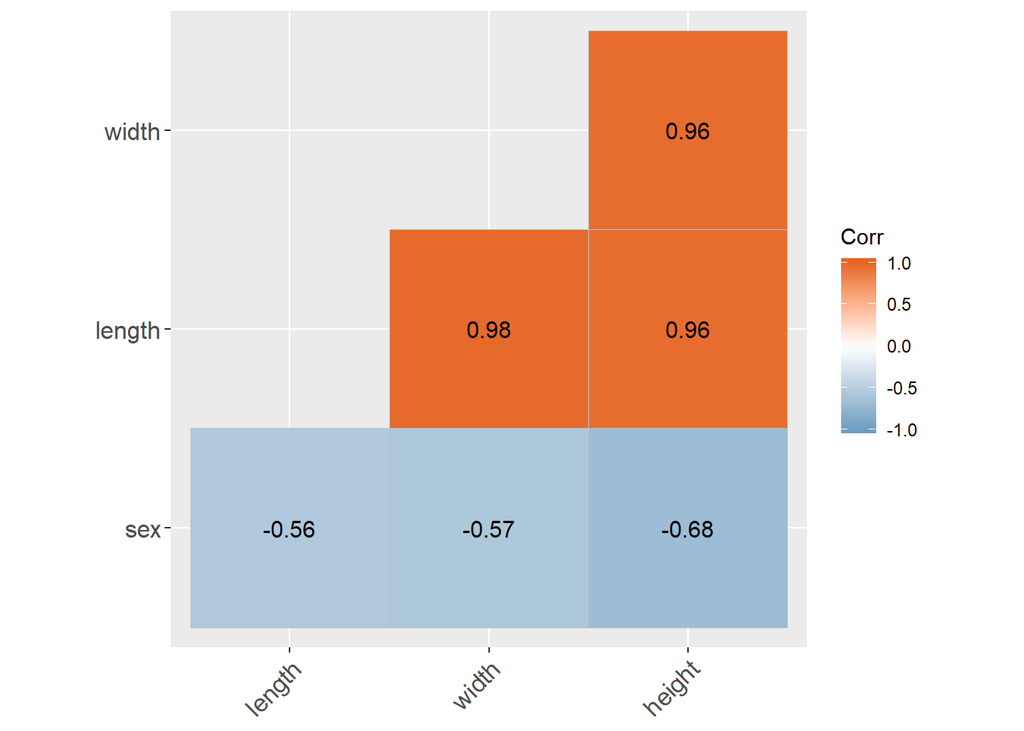

```r
turtles_num = turtles %>% mutate(sex=ifelse(sex=="f",0,1))
turt_cor = cor(turtles_num)

ggcorrplot(turt_cor, type = "lower", lab = TRUE,
           ggtheme = ggplot2::theme_gray,
           colors = c("#6D9EC1", "white", "#E46726"))
```

Strong positive correlation in width and height, length and width and, length and height.

Moderate negative correlation in sex and the other 3 measurments (note 0 is female and 1 is male).

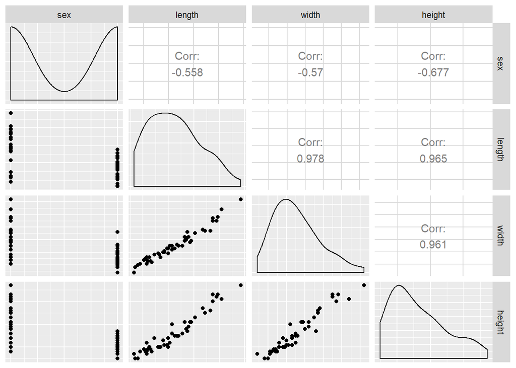

```r
ggpairs(turtles_num, axisLabels = "none")
```

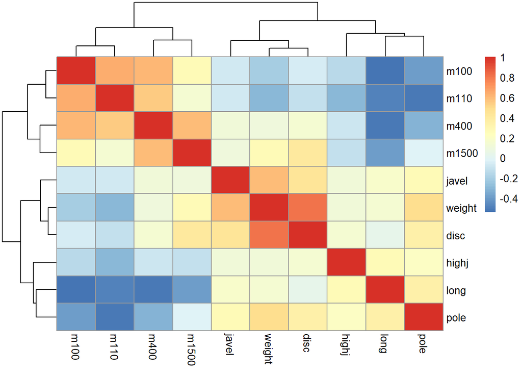

```r
library("pheatmap")
pheatmap(cor(athletes), cell.width = 10, cell.height = 10)
```

## 7.2.2 Preprocessing the data

```r
# normal
apply(turtles[,-1], 2, sd)
```

```
##    length     width    height
## 20.481602 12.675838  8.392837
```

```r
apply(turtles[,-1], 2, mean)
```

```
##    length     width    height
## 124.68750  95.43750  46.33333
```

```r
# scaled
scaledTurtles = scale(turtles[, -1])

apply(scaledTurtles, 2, mean)
```

```
##        length         width        height
## -1.432050e-18  1.940383e-17 -2.870967e-16
```

```r
apply(scaledTurtles, 2, sd)
```

```
## length  width height
##      1      1      1
```

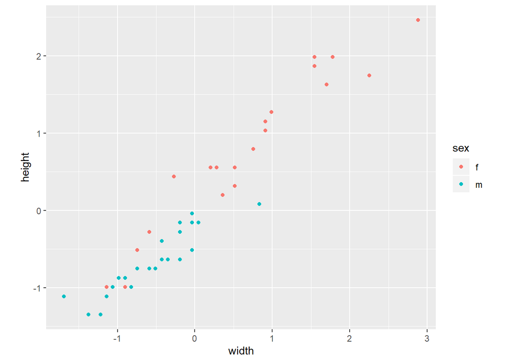

```r
data.frame(scaledTurtles, sex = turtles[, 1]) %>%
  ggplot(aes(x = width, y = height, group = sex)) +
    geom_point(aes(color = sex)) + coord_fixed()
```

# 7.3 Dimension reduction

## 7.3.1 Lower-dimensional projections

here is one example of going from 2d to 1d

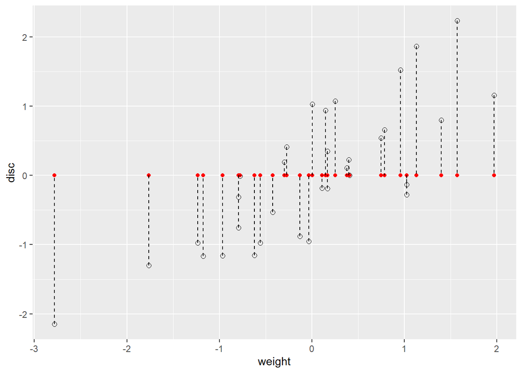

```r
athletes_scale = data.frame(scale(athletes))

ath_gg = ggplot(athletes_scale, aes(x = weight, y = disc)) +
  geom_point(size = 2, shape = 21)

ath_gg + geom_point(aes(y = 0), colour = "red") +
  geom_segment(aes(xend = weight, yend = 0), linetype = "dashed")
```

the variance is just the variance of the weight, scaled or not.

```r
var(scale(athletes$weight))
```

```
##      [,1]
## [1,]    1
```

We can also project to the y axis

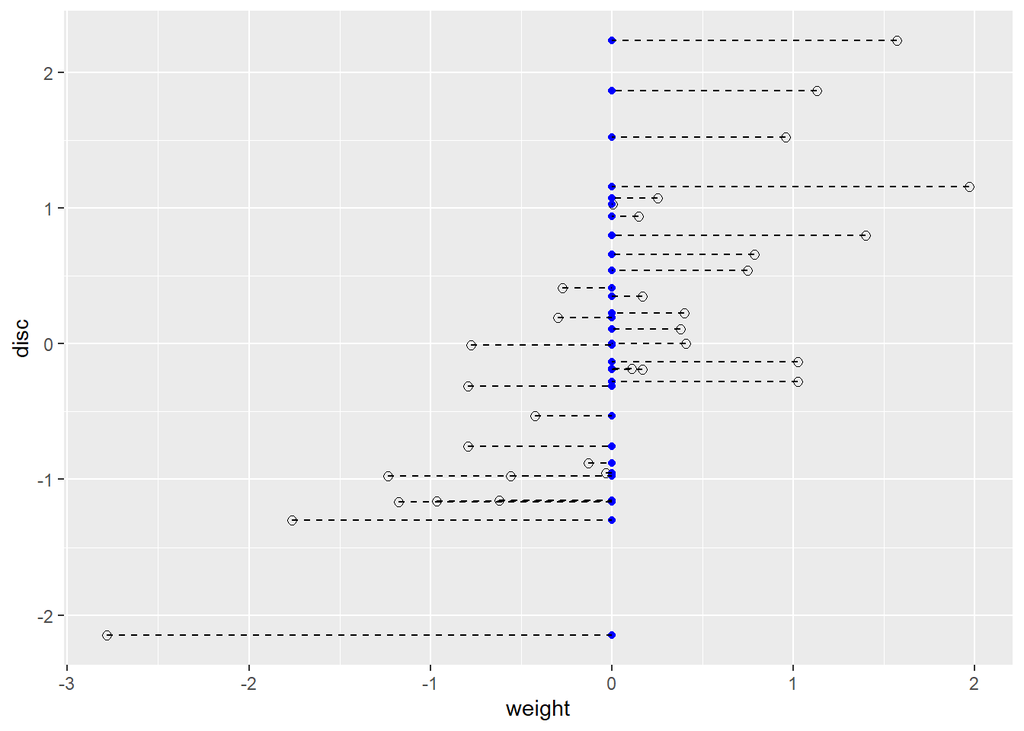

```r
ath_gg = ggplot(athletes_scale, aes(x = weight, y = disc)) +
  geom_point(size = 2, shape = 21)

ath_gg + geom_point(aes(x = 0), colour = "blue") +
  geom_segment(aes(yend = disc, xend = 0), linetype = "dashed")
```

the variance is just the variance of the disc, scaled or not.

```r
var((athletes$disc))
```

```
## [1] 13.83194
```

## 7.3.2 How do we summarize two-dimensional data by a line?

Of course doing what we just did loses all of the infomration about the other variables.

One idea that we can use is regression, it too will reduce our 2d problem to a 1d line, but still keep info about both variables.

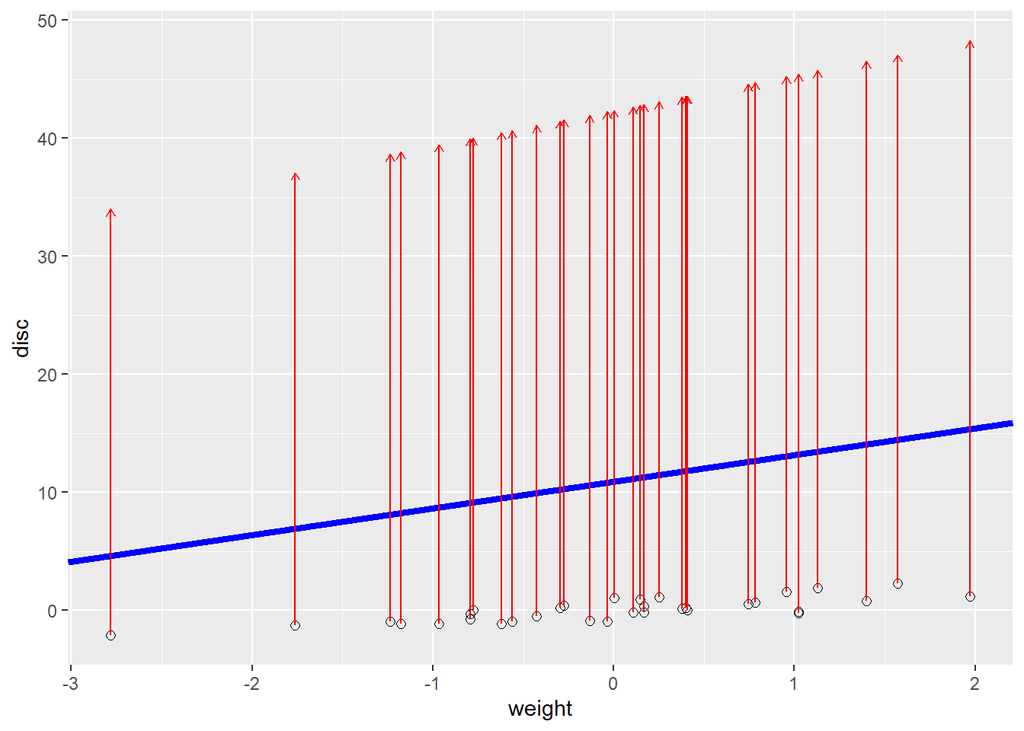

```r
reg1 = lm(disc ~ weight, data = athletes)
a1 = reg1$coefficients[1] # intercept
b1 = reg1$coefficients[2] # slope
pline1 = ath_gg + geom_abline(intercept = a1, slope = b1,
    col = "blue", lwd = 1.5)
pline1 + geom_segment(aes(xend = weight, yend = reg1$fitted),
    colour = "red", arrow = arrow(length = unit(0.15, "cm")))
```

```r
var(athletes$weight) + var(reg1$fitted)
```

```
## [1] 10.76778
```

We can also minimize the distance in both the x and y direction, we will see this is a big idea in PCA

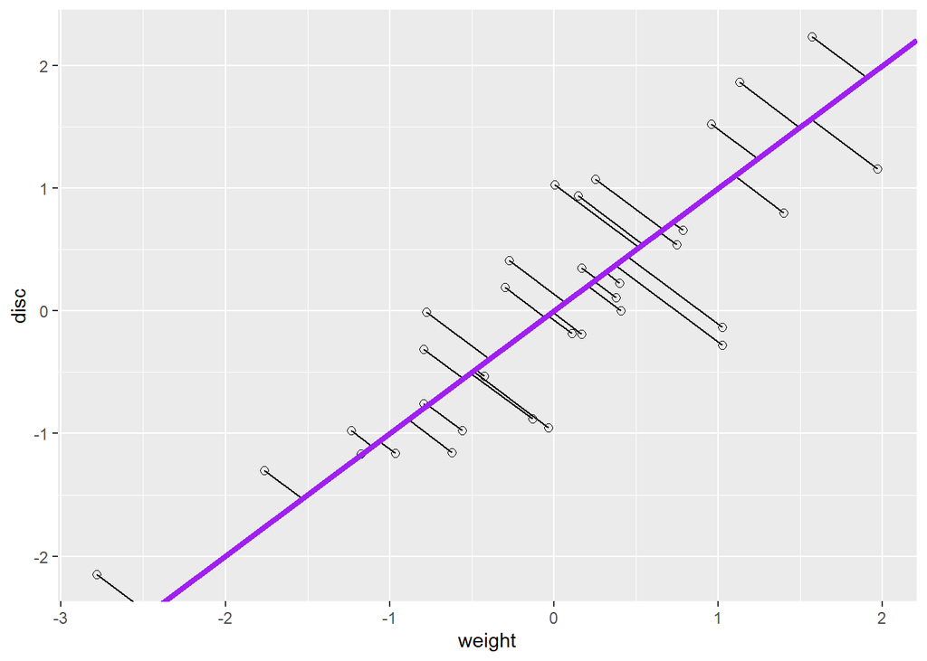

```r
xy = cbind(scale(athletes$disc), scale(athletes$weight))
svda = svd(xy)
pc = xy %*% svda$v[, 1] %*% t(svda$v[, 1])
bp = svda$v[2, 1] / svda$v[1, 1]
ap = mean(pc[, 2]) - bp * mean(pc[, 1])
ath_gg + geom_segment(xend = pc[, 1], yend = pc[, 2]) +
  geom_abline(intercept = ap, slope = bp, col = "purple", lwd = 1.5)
```

# 7.4 The new linear combinations

A principal component is simiply a linear combination the variables that we wish to reduce in dimension.

The coffiecents that make us this linear comboination are called **loadings**.

Once we apply the linear combination to the data, we get the principal component.

# 7.5 The PCA workflow

The big picture idea for PCA is to find the axis (variable) that shows the most variability, then iterate to find the next and so forth.

However, we do not need to iterate, but rather we can decompose our data using Singular Value Decomposition.

Of course there is alot of choices that we have to make. For example, do we use scaled data, and how many PC’s do we use?

# 7.6 The inner workings of PCA: rank reduction

SVD takes a matrix A and decomposes as follows $A = U\Sigma V^T$ where:

- A is a $m\times n$ matrix
- U is a $m \times m$ orthogonal matrix
- $\Sigma$ is a $m \times n$ diagonal matrix
- V is a $n \times n$ orthogonal matrix

Note that U and V contain the singular vectors, and $\Sigma$ contains the singular values.

## Case of rank one

This almost never happens

## All other cases

One thing that gets me here, is that we focus on using SVD but never look at the other approach where we find the eigen values and vectors of the covariance matrix.

```r
Xtwo = matrix(c(12.5, 35.0, 25.0, 25, 9, 14, 26, 18, 16, 21, 49, 32,

       18, 28, 52, 36, 18, 10.5, 64.5, 36), ncol = 4, byrow = TRUE)
USV = svd(Xtwo)

USV$d[1] %*% USV$u[,1]
```

```
##           [,1]      [,2]      [,3]      [,4]      [,5]
## [1,] -46.50379 -35.67916 -64.19226 -71.35832 -74.79024
```

# 7.7 Plotting the observations in the principal plane

What part of the output of the svd functions leads us to the first PC coefficients, also known as the PC loadings ?

This would be the “v” matrix, in partiular the first column gives us the first set of loadings.

Let’s get right into things by performing PCA on the athletes data

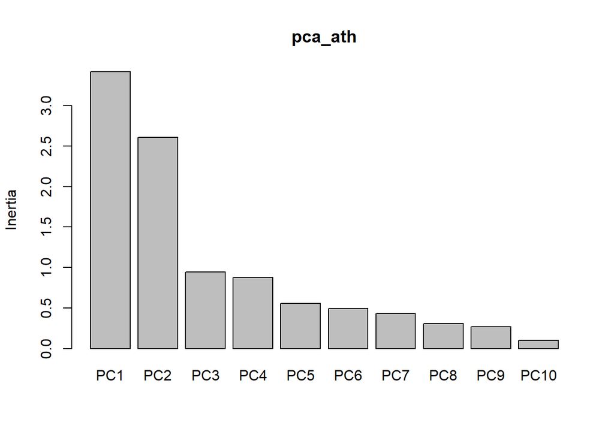

```r
pca_ath = prcomp(athletes,scale=T)


screeplot(pca_ath)
```

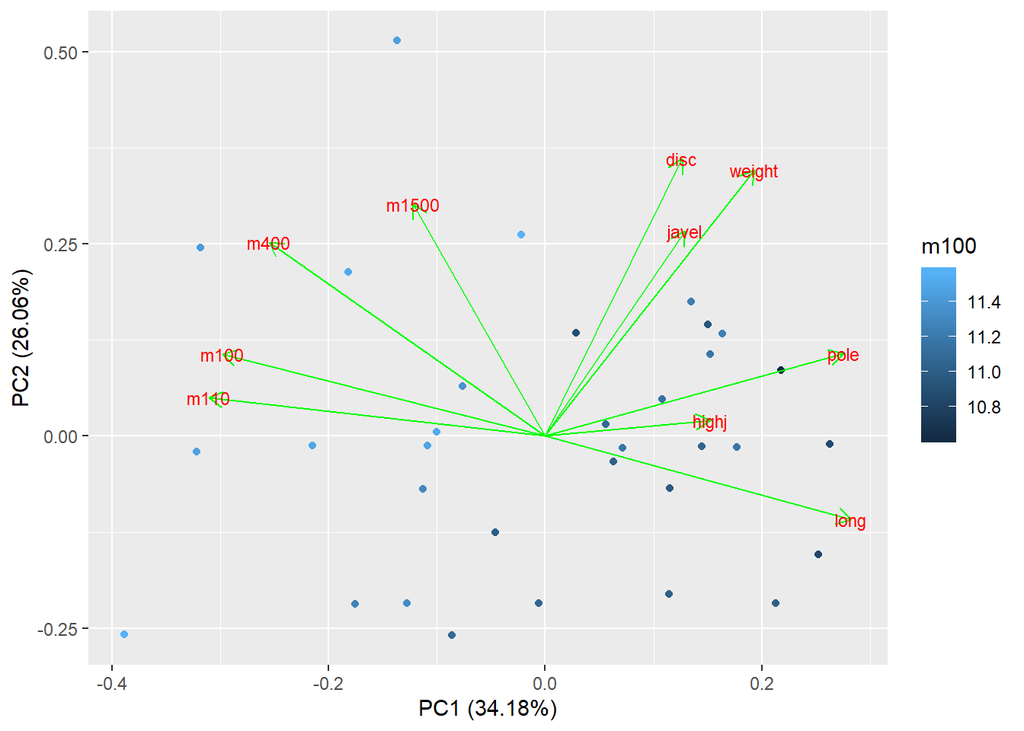

```r
autoplot(pca_ath,data=athletes,colour="m100",loadings = TRUE,
         loadings.colour = 'green',loadings.label = TRUE, loadings.label.size = 3)
```

So, what does this tell us?

If we focus in on the first two PC’s then we can plot a bi-plot. This shows us that the first PC is mainly driven by events that require running or jumping, where as the second PC is mostly driven by events that require throwing.

Also, note the negative weights on the race variable (m100,m110,etc…). This is the case since the original measure was time, and being “good” at the race typically means having a shorter time. This negative correlation (greater than 90 degree angle) with the jumping variables was also seen with the heat map we produced above.